# Zadania z laboratorium 5 i laboratorium 6

## Zadanie 6. - wstępna analiza danych

```r
dane=read.csv("C:/Users/asus/Desktop/dane7.csv")

#a)
#Jest to baza danych na podstawie badania S. Quine z 1975 roku, które sprawdza zależność między płcią, rasą, rodzajem szkoły i tym, jak dobre jest dziecko w nauce, a liczbą opuszczonych przez nie dni (response variable). Zawiera ona 154 obserwacje.

#b)
#zmienne ilościowe: liczba opuszczonych dni(absent)
#zmienne jakościowe: rasa (race), płeć (sex), rodzaj szkoły (school), prędkość nauki dziecka (learner)

dane$race=as.factor(dane$race)
dane$sex=as.factor(dane$sex)
dane$school=as.factor(dane$school)
dane$learner=as.factor(dane$learner)

sum(is.na(dane)) #dane są kompletne, nie ma braków
```

```
## [1] 0
```

```r
#c)
tr1=table(dane$race, dane$sex)
tr1
```

```
##
##                  female male
##   aboriginal         41   33
##   non-aboriginal     43   37
```

```r
prop.table(tr1)
```

```
##
##                     female      male
##   aboriginal     0.2662338 0.2142857
##   non-aboriginal 0.2792208 0.2402597
```

```r
prop.table(table(dane$school))
```

```
##
##        F0        F1        F2        F3
## 0.1753247 0.3116883 0.2467532 0.2662338
```

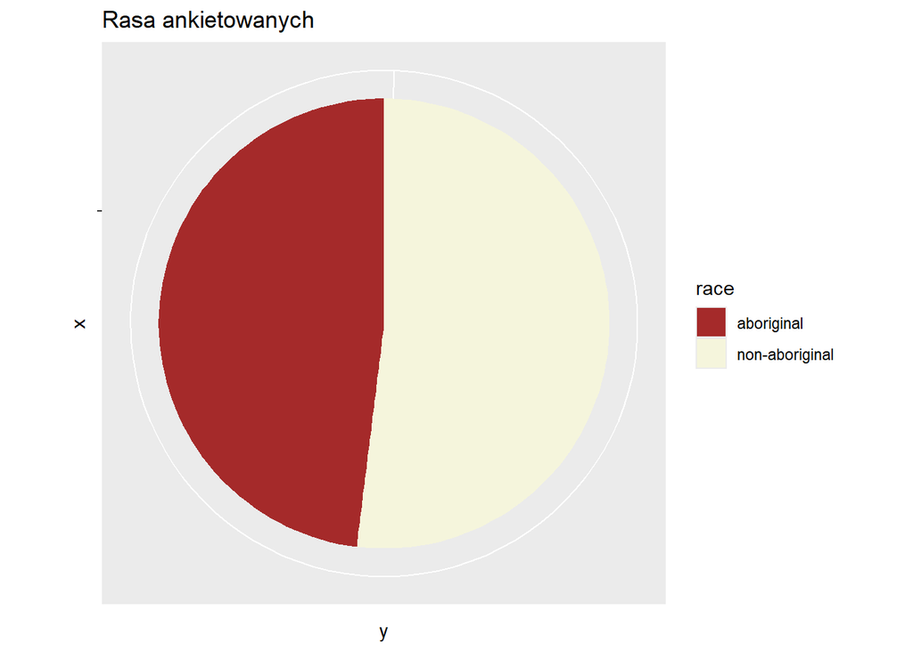

```r
ggplot(dane, aes(x="", y="", fill=race))+
  geom_bar(stat="identity",width = 1) +
  coord_polar("y")+
  labs(title = "Rasa ankietowanych")+
  scale_fill_manual(values=c("brown", "beige"))
```

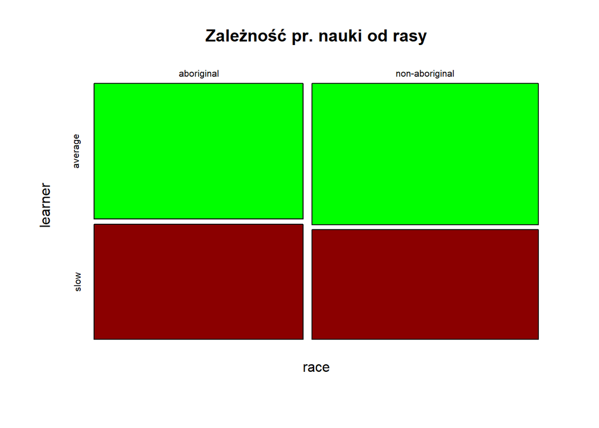

```r
mosaicplot(~race+learner, dane, col=c("green", "red4"), main="Zależność pr. nauki od rasy")
```

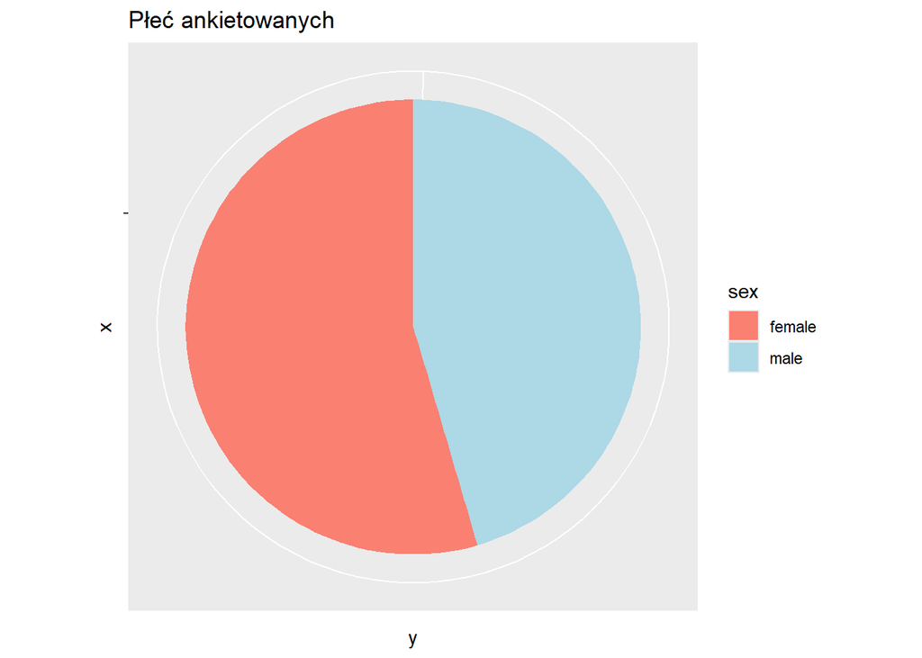

```r
ggplot(dane, aes(x="", y="", fill=sex))+
  geom_bar(stat="identity",width = 1) +
  coord_polar("y")+
  labs(title = "Płeć ankietowanych")+
  scale_fill_manual(values=c("salmon", "lightblue"))
```

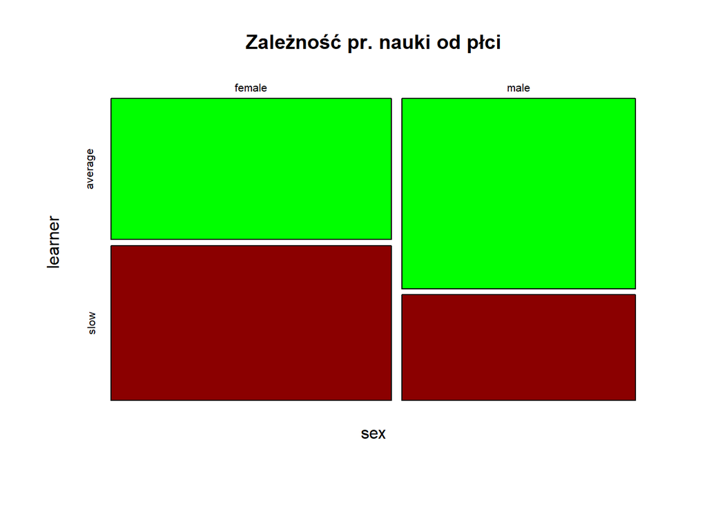

```r
mosaicplot(~sex+learner, dane, col=c("green", "red4"), main="Zależność pr. nauki od płci")
```

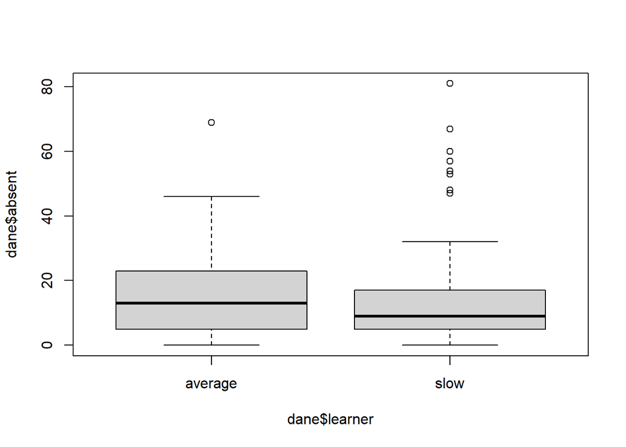

```r
library(car)
boxplot(dane$absent ~ dane$learner)
```

```r
#Wnioski są na końcu

#d)
library(RVAideMemoire)
library(moments)

med_abs=median(dane$absent)
sr_abs=mean(dane$absent)
mod_abs=mod(dane$absent)
odch_st=sd(dane$absent)
war=var(dane$absent)
skosnosc=skewness(dane$absent)
kur=kurtosis(dane$absent)

list(mediana=med_abs, średnia=sr_abs, moda=mod_abs, odchylenie_standardowe=odch_st, wariancja=war, skośność=skosnosc, kurtoza=kur)
```

```
## $mediana
## [1] 11
##
## $średnia
## [1] 16.13636
##
## $moda
## [1] 5
##
## $odchylenie_standardowe
## [1] 15.90539
##
## $wariancja
## [1] 252.9813
##
## $skośność
## [1] 1.594619
##
## $kurtoza
## [1] 5.400476
```

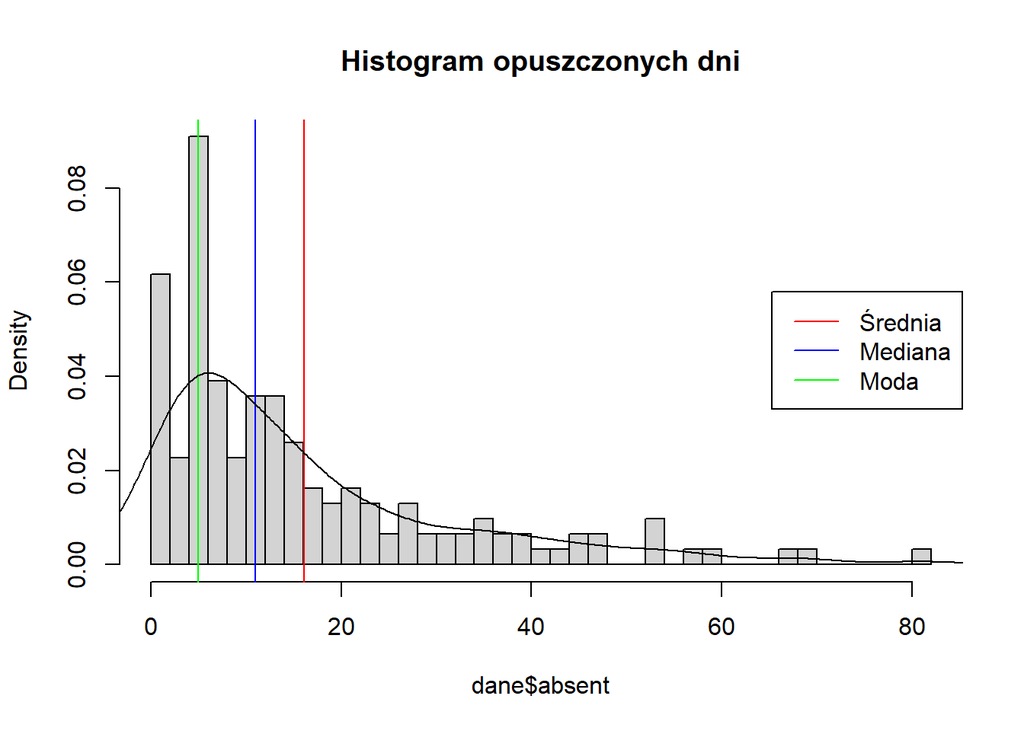

```r
hist(dane$absent, breaks=30, main="Histogram opuszczonych dni", probability = TRUE)
abline(v=sr_abs, col="red")
abline(v=med_abs, col="blue")
abline(v=mod_abs, col="green")
lines(density(dane$absent))
legend("right", legend=c("Średnia", "Mediana", "Moda"), col=c("red", "blue", "green"), lwd=c(1,1))
```

Wnioski na podstawie tabelek i wykresów(c):  
- w bazie danych jest równowaga wpisów pod względem płci i rasy, natomiast pod względem poziomu szkoły odstają zmienne F0 (b. mało wpisów) i F1 (b. dużo wpisów)  
- nie możemy zaobserwować żadnej zależności między rasą a prędkością nauki, natomiast istnieje zależność między płcią i prędkością nauki (średnio większy procent kobiet jest “slow learner”)  
- co ciekawe, “average learners” opuszczają średnio więcej dni, niż ich “slow” koledzy i koleżanki  
- uczniowie na ogół nie opuszczają za wielu dni (mediana wynosi 11); średnia (ok. 16,1) jest zawyżona zapewne przez pojedyczne osoby z nieobecnoscią na poziomie >50; na temat histogramu rozpiszę się poniżej.  
Należy mieć na uwadze, że to mały zbiór danych (154 wpisów), i o ile daje jakiś obraz sytuacji, o tyle absolutnie należy uważać z generalizacjami typu “kobiety uczą się średnio gorzej niż mężczyźni”.